# Improving marketing strategies and customer satisfaction.

### Metric for success

The company needs to identify distinct customer segments to tailor marketing efforts more effectively and enhance customer experience.

## The Dataset

The Mall Customers dataset contains information about customers, including:

1. CustomerID: Unique identifier for each customer.
2. Genre: Gender of the customer.
3. Age: Age of the customer.
4. Annual Income (k$): Annual income of the customer in thousands of dollars.
5. Spending score (1-100): Score assigned by the mall based on customer behavior and spending.

### Recording the Experimental Design

#### Objectives

```
  1.Primary Objective: Identify distinct customer segments based on demographic information, annual income, and spending             scores to improve targeted marketing strategies.

  2.Secondary Objectives:
       . Understand the spending behavior of different customer segments.
       . Analyze the impact of demographic factors (age and gender) on spending scores.
       . Predict customer spending scores using demographic and income data.
```

### Data Relevance

The data helps us perform descriptive statistics and visualizations to understand data distributions and relationships.

Segmentation and Clustering: - Apply clustering algorithms to segment customers. - Validate and interpret the characteristics of each segment.

Spending Behavior Analysis: - Conduct correlation analysis to identify relationships between variables. - Use regression models to predict spending scores.

Demographic Analysis: - Use statistical tests to compare spending scores across different demographic groups. - Visualize differences using appropriate charts.

## 2. Reading the Data

```python
import pandas as pd
import seaborn as sns
import matplotlib.pyplot as plt
from sklearn.decomposition import PCA
from sklearn.preprocessing import StandardScaler
from sklearn.feature_selection import RFE
from sklearn.linear_model import LogisticRegression

# Load the dataset
url = 'http://bit.ly/MallCustomersDataset'
Mall_customers = pd.read_csv(url)

print("\nDataset loaded successfully:")
print(Mall_customers.head())
print("\nDataset information:")
```

```
Dataset loaded successfully:
   CustomerID   Genre  Age  Annual Income (k$)  Spending Score (1-100)
0           1    Male   19                  15                      39
1           2    Male   21                  15                      81
2           3  Female   20                  16                       6
3           4  Female   23                  16                      77
4           5  Female   31                  17                      40

Dataset information:
```

## 3. Checking the Data

```python
# Determining the no. of records in our dataset
#
num_records = Mall_customers.shape[0]
print(f"The number of records in the dataset is: {num_records}")
```

```
The number of records in the dataset is: 200
```

```python
# Previewing the top of our dataset
#
Mall_customers.head()
```

|  | CustomerID | Genre | Age | Annual Income (k$) | Spending Score (1-100) |
| --- | --- | --- | --- | --- | --- |
| 0 | 1 | Male | 19 | 15 | 39 |
| 1 | 2 | Male | 21 | 15 | 81 |
| 2 | 3 | Female | 20 | 16 | 6 |
| 3 | 4 | Female | 23 | 16 | 77 |
| 4 | 5 | Female | 31 | 17 | 40 |

```python
# Previewing the bottom of our dataset
#
Mall_customers.tail()
```

|  | CustomerID | Genre | Age | Annual Income (k$) | Spending Score (1-100) |
| --- | --- | --- | --- | --- | --- |
| 195 | 196 | Female | 35 | 120 | 79 |
| 196 | 197 | Female | 45 | 126 | 28 |
| 197 | 198 | Male | 32 | 126 | 74 |
| 198 | 199 | Male | 32 | 137 | 18 |
| 199 | 200 | Male | 30 | 137 | 83 |

```python
# Checking whether each column has an appropriate datatype
#
print("\nChecking if each column has an appropriate datatype:")
expected_dtypes = {
    'CustomerID': 'int64',
    'Genre': 'object',
    'Age': 'int64',
    'Annual Income (k$)': 'int64',
    'Spending Score (1-100)': 'int64'
}

for column, expected_dtype in expected_dtypes.items():
    actual_dtype = Mall_customers[column].dtype
    if actual_dtype == expected_dtype:
        print(f"Column '{column}' has the correct datatype: {actual_dtype}")
    else:
        print(f"Column '{column}' has an incorrect datatype: {actual_dtype}. Expected: {expected_dtype}")
```

```
Checking if each column has an appropriate datatype:
Column 'CustomerID' has the correct datatype: int64
Column 'Genre' has the correct datatype: object
Column 'Age' has the correct datatype: int64
Column 'Annual Income (k$)' has the correct datatype: int64
Column 'Spending Score (1-100)' has the correct datatype: int64
```

## 4. External Data Source Validation

### External data source validation is crucial to ensure the integrity, accuracy, and reliability of the data being used in analysis.

### Key steps for validating an external data source:

Here are the key steps for validating an external data source:

Source Credibility: - Verify the credibility and reliability of the data source.

Data Consistency: - Check for consistency and completeness in the data.

Data Accuracy: - Compare the data with known benchmarks or other reliable sources.

Data Timeliness: - Ensure the data is up-to-date and relevant for the analysis.

Data Documentation: - Review any accompanying documentation or metadata for the data.

## 5. Handling Outliers

```
Q1 for Age: 28.75, Q3 for Age: 49.0, IQR: 20.25
Lower bound for Age: -1.625, Upper bound for Age: 79.375

Outliers in 'Age':
Empty DataFrame
Columns: [CustomerID, Genre, Age, Annual Income (k$), Spending Score (1-100)]
Index: []
Q1 for Annual Income (k$): 41.5, Q3 for Annual Income (k$): 78.0, IQR: 36.5
Lower bound for Annual Income (k$): -13.25, Upper bound for Annual Income (k$): 132.75

Outliers in 'Annual Income (k$)':
     CustomerID Genre  Age  Annual Income (k$)  Spending Score (1-100)
198         199  Male   32                 137                      18
199         200  Male   30                 137                      83
Q1 for Spending Score (1-100): 34.75, Q3 for Spending Score (1-100): 73.0, IQR: 38.25
Lower bound for Spending Score (1-100): -22.625, Upper bound for Spending Score (1-100): 130.375

Outliers in 'Spending Score (1-100)':
Empty DataFrame
Columns: [CustomerID, Genre, Age, Annual Income (k$), Spending Score (1-100)]
Index: []
```

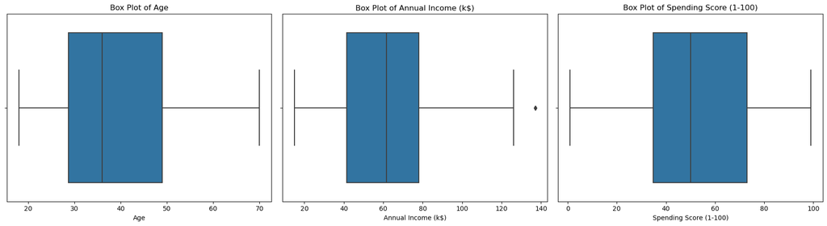

```python
# Checking for Outliers
## Identifying outliers using the IQR method
def detect_outliers(df, column):
    Q1 = df[column].quantile(0.25)
    Q3 = df[column].quantile(0.75)
    IQR = Q3 - Q1
    lower_bound = Q1 - 1.5 * IQR
    upper_bound = Q3 + 1.5 * IQR
    outliers = df[(df[column] < lower_bound) | (df[column] > upper_bound)]
    print(f"Q1 for {column}: {Q1}, Q3 for {column}: {Q3}, IQR: {IQR}")
    print(f"Lower bound for {column}: {lower_bound}, Upper bound for {column}: {upper_bound}")
    return outliers


## Checking for outliers in numerical columns
numerical_columns = ['Age', 'Annual Income (k$)', 'Spending Score (1-100)']
for column in numerical_columns:
    outliers = detect_outliers(Mall_customers, column)
    print(f"\nOutliers in '{column}':")
    print(outliers)

#Visualizing with box plots
plt.figure(figsize=(18, 5))
for i, column in enumerate(numerical_columns):
        plt.subplot(1, 3, i+1)
        sns.boxplot(x=Mall_customers[column])
        plt.title(f'Box Plot of {column}')

plt.tight_layout()
plt.show()
```

```python
# Checking for Anomalies
print("\nChecking for missing data in each column:")
missing_data = Mall_customers.isnull().sum()
print(missing_data)
```

```
Checking for missing data in each column:
CustomerID                0
Genre                     0
Age                       0
Annual Income (k$)        0
Spending Score (1-100)    0
dtype: int64
```

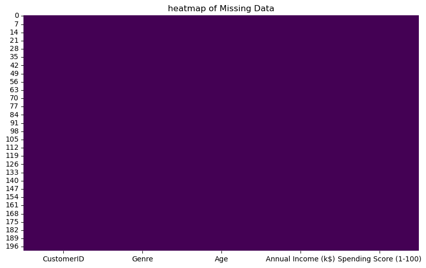

```python
# Identifying the Missing Data

## Visualizing missing data
plt.figure(figsize=(10, 6))
sns.heatmap(Mall_customers.isnull(), cbar=False, cmap='viridis')
plt.title('heatmap of Missing Data')
plt.show()
```

```python
# Dealing with the Missing Data
# Very that missing data is handled
Mall_customers.loc[:, 'Age'] = Mall_customers['Age'].fillna(Mall_customers['Age'].mean())
Mall_customers.loc[:, 'Annual Income (k$)'] = Mall_customers['Annual Income (k$)'].fillna(Mall_customers['Annual Income (k$)'].mean())
Mall_customers.loc[:, 'Spending Score (1-100)'] = Mall_customers['Spending Score (1-100)'].fillna(Mall_customers['Spending Score (1-100)'].mean())
Mall_customers.loc[:, 'Genre'] = Mall_customers['Genre'].fillna(Mall_customers['Genre'].mode()[0])
```

```python
## More data cleaning procedures
# Removing duplicate records
Mall_customers.drop_duplicates(inplace=True)
print("\nDataset shape after removing duplicates:", Mall_customers.shape)

# Handling outliers using IQR method
def remove_outliers(df, column):
    Q1 = df[column].quantile(0.25)
    Q3 = df[column].quantile(0.75)
    IQR = Q3 - Q1
    lower_bound = Q1 - 1.5 * IQR
    upper_bound = Q3 + 1.5 * IQR
    return df[(df[column] >= lower_bound) & (df[column] <= upper_bound)]

for column in ['Age', 'Annual Income (k$)', 'Spending Score (1-100)']:
    Mall_customers = remove_outliers(Mall_customers, column)

print("\nDataset shape after removing outliers:", Mall_customers.shape)

# Ensuring correct data types
Mall_customers['CustomerID'] = Mall_customers['CustomerID'].astype(int)
Mall_customers['Age'] = Mall_customers['Age'].astype(int)
Mall_customers['Annual Income (k$)'] = Mall_customers['Annual Income (k$)'].astype(int)
Mall_customers['Spending Score (1-100)'] = Mall_customers['Spending Score (1-100)'].astype(int)

# Encoding categorical variables
Mall_customers['Genre'] = Mall_customers['Genre'].map({'Male': 0, 'Female': 1})

# Renaming columns for better readability
Mall_customers.rename(columns={'Genre': 'Gender', 'Annual Income (k$)': 'Annual_Income', 'Spending Score (1-100)': 'Spending_Score'}, inplace=True)

# Summary statistics after cleaning
print("\nSummary statistics for numerical columns after cleaning:")
print(Mall_customers.describe())
```

```
Dataset shape after removing duplicates: (200, 5)

Dataset shape after removing outliers: (198, 5)

Summary statistics for numerical columns after cleaning:
       CustomerID      Gender         Age  Annual_Income  Spending_Score
count  198.000000  198.000000  198.000000     198.000000      198.000000
mean    99.500000    0.565657   38.929293      59.787879       50.196970
std     57.301832    0.496927   14.016852      25.237259       25.746846
min      1.000000    0.000000   18.000000      15.000000        1.000000
25%     50.250000    0.000000   28.250000      40.500000       35.000000
50%     99.500000    1.000000   36.000000      61.000000       50.000000
75%    148.750000    1.000000   49.000000      77.750000       72.750000
max    198.000000    1.000000   70.000000     126.000000       99.000000
```

## 6. Exploratory Analysis

```
Column names: ['CustomerID', 'Genre', 'Age', 'Annual Income (k$)', 'Spending Score (1-100)']
Updated column names: ['CustomerID', 'Genre', 'Age', 'Annual_Income', 'Spending_Score']

Data types:
 CustomerID        int64
Genre             int64
Age               int64
Annual_Income     int64
Spending_Score    int64
dtype: object

Missing values:
 CustomerID        0
Genre             0
Age               0
Annual_Income     0
Spending_Score    0
dtype: int64
       CustomerID       Genre         Age  Annual_Income  Spending_Score
count  200.000000  200.000000  200.000000     200.000000      200.000000
mean   100.500000    0.560000   38.850000      60.560000       50.200000
std     57.879185    0.497633   13.969007      26.264721       25.823522
min      1.000000    0.000000   18.000000      15.000000        1.000000
25%     50.750000    0.000000   28.750000      41.500000       34.750000
50%    100.500000    1.000000   36.000000      61.500000       50.000000
75%    150.250000    1.000000   49.000000      78.000000       73.000000
max    200.000000    1.000000   70.000000     137.000000       99.000000
                CustomerID     Genre       Age  Annual_Income  Spending_Score
CustomerID        1.000000 -0.057400 -0.026763       0.977548        0.013835
Genre            -0.057400  1.000000 -0.060867      -0.056410        0.058109
Age              -0.026763 -0.060867  1.000000      -0.012398       -0.327227
Annual_Income     0.977548 -0.056410 -0.012398       1.000000        0.009903
Spending_Score    0.013835  0.058109 -0.327227       0.009903        1.000000
```

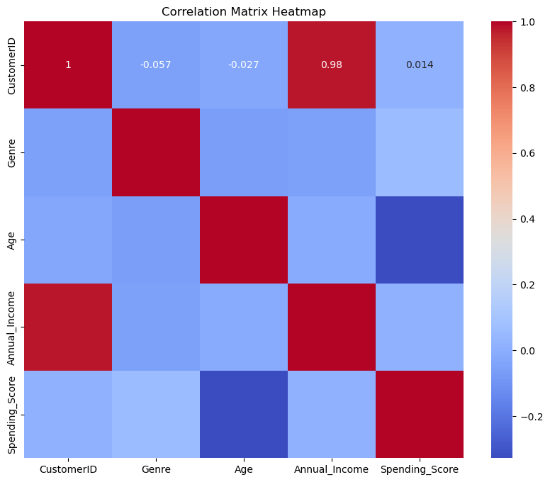

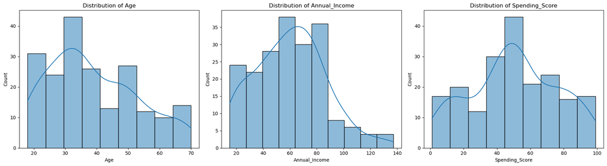

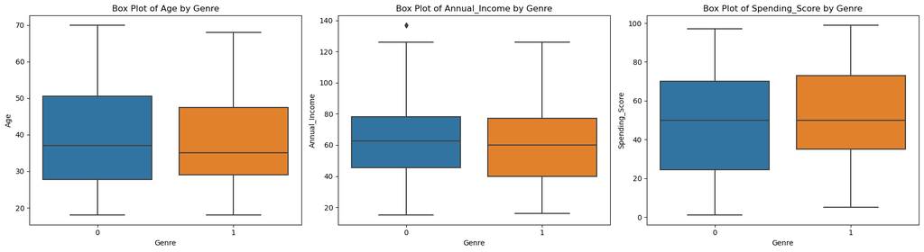

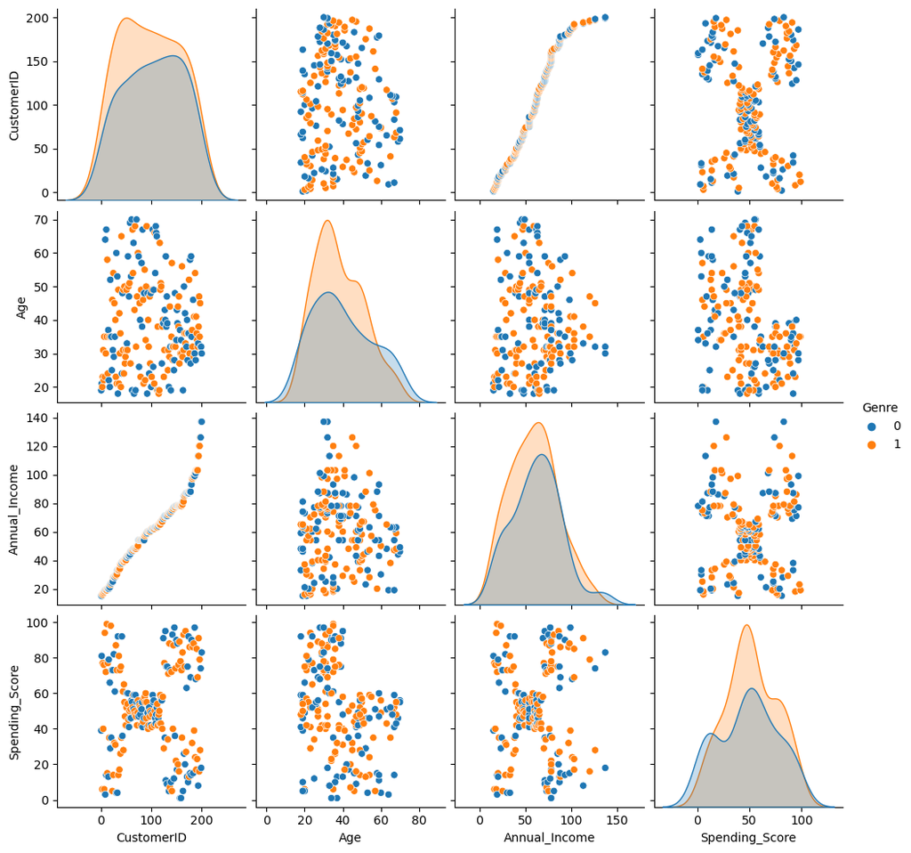

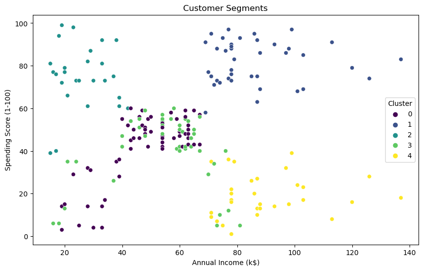

```
                            OLS Regression Results
==============================================================================
Dep. Variable:         Spending_Score   R-squared:                       0.109
Model:                            OLS   Adj. R-squared:                  0.095
Method:                 Least Squares   F-statistic:                     7.960
Date:                Fri, 14 Jun 2024   Prob (F-statistic):           4.91e-05
Time:                        00:37:50   Log-Likelihood:                -922.05
No. Observations:                 200   AIC:                             1852.
Df Residuals:                     196   BIC:                             1865.
Df Model:                           3
Covariance Type:            nonrobust
=================================================================================
                    coef    std err          t      P>|t|      [0.025      0.975]
---------------------------------------------------------------------------------
const            71.9168      7.023     10.240      0.000      58.067      85.767
Age              -0.6004      0.125     -4.806      0.000      -0.847      -0.354
Annual_Income     0.0079      0.066      0.119      0.905      -0.123       0.139
Genre             2.0132      3.512      0.573      0.567      -4.913       8.939
==============================================================================
Omnibus:                       11.059   Durbin-Watson:                   3.448
Prob(Omnibus):                  0.004   Jarque-Bera (JB):                6.033
Skew:                          -0.233   Prob(JB):                       0.0490
Kurtosis:                       2.288   Cond. No.                         312.
==============================================================================

Notes:
[1] Standard Errors assume that the covariance matrix of the errors is correctly specified.
Genre
0    48.511364
1    51.526786
Name: Spending_Score, dtype: float64
```

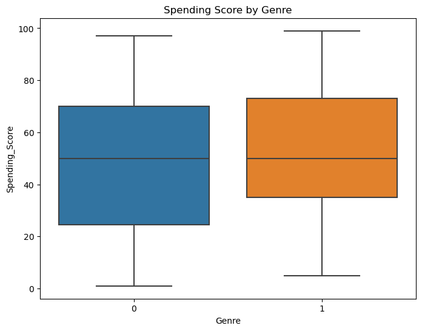

```python
import pandas as pd
import seaborn as sns
import matplotlib.pyplot as plt
from sklearn.cluster import KMeans
from sklearn.preprocessing import StandardScaler
import statsmodels.api as sm
import numpy as np

# Load the dataset
url = 'http://bit.ly/MallCustomersDataset'
Mall_customers = pd.read_csv(url)

# Inspect column names
print("Column names:", Mall_customers.columns.tolist())

# Clean and standardize column names
Mall_customers.columns = Mall_customers.columns.str.strip()
Mall_customers.rename(columns={'Annual Income (k$)': 'Annual_Income', 'Spending Score (1-100)': 'Spending_Score'}, inplace=True)

# Verify the updated column names
print("Updated column names:", Mall_customers.columns.tolist())

# Data Preprocessing
Mall_customers.drop_duplicates(inplace=True)

# Convert infinite values to NaN
Mall_customers.replace([np.inf, -np.inf], np.nan, inplace=True)

# Handle missing values
Mall_customers['Age'] = Mall_customers['Age'].fillna(Mall_customers['Age'].mean())
Mall_customers['Annual_Income'] = Mall_customers['Annual_Income'].fillna(Mall_customers['Annual_Income'].mean())
Mall_customers['Spending_Score'] = Mall_customers['Spending_Score'].fillna(Mall_customers['Spending_Score'].mean())
Mall_customers['Genre'] = Mall_customers['Genre'].fillna(Mall_customers['Genre'].mode()[0])

# Encode categorical variables
Mall_customers['Genre'] = Mall_customers['Genre'].map({'Male': 0, 'Female': 1})

# Verify data types and missing values
print("\nData types:\n", Mall_customers.dtypes)
print("\nMissing values:\n", Mall_customers.isnull().sum())

# Standardize the data
scaler = StandardScaler()
scaled_features = scaler.fit_transform(Mall_customers[['Age', 'Annual_Income', 'Spending_Score']])

# Exploratory Data Analysis
# Descriptive statistics
print(Mall_customers.describe())

# Correlation analysis
correlation_matrix = Mall_customers.corr()
print(correlation_matrix)

# Visualize the correlation matrix
plt.figure(figsize=(10, 8))
sns.heatmap(correlation_matrix, annot=True, cmap='coolwarm')
plt.title('Correlation Matrix Heatmap')
plt.show()

# Distribution plots for numerical columns
plt.figure(figsize=(18, 5))
for i, column in enumerate(['Age', 'Annual_Income', 'Spending_Score']):
    plt.subplot(1, 3, i+1)
    sns.histplot(Mall_customers[column], kde=True)
    plt.title(f'Distribution of {column}')
plt.tight_layout()
plt.show()

# Box plots for numerical columns by Genre
plt.figure(figsize=(18, 5))
for i, column in enumerate(['Age', 'Annual_Income', 'Spending_Score']):
    plt.subplot(1, 3, i+1)
    sns.boxplot(x='Genre', y=column, data=Mall_customers)
    plt.title(f'Box Plot of {column} by Genre')
plt.tight_layout()
plt.show()

# Pairplot to visualize relationships
sns.pairplot(Mall_customers, hue='Genre')
plt.show()

# Apply K-means clustering
kmeans = KMeans(n_clusters=5, random_state=42)
Mall_customers['Cluster'] = kmeans.fit_predict(scaled_features)

# Visualize the clusters
plt.figure(figsize=(10, 6))
sns.scatterplot(x=Mall_customers['Annual_Income'], y=Mall_customers['Spending_Score'], hue=Mall_customers['Cluster'], palette='viridis')
plt.title('Customer Segments')
plt.xlabel('Annual Income (k$)')
plt.ylabel('Spending Score (1-100)')
plt.show()

# Regression analysis
X = Mall_customers[['Age', 'Annual_Income', 'Genre']]
y = Mall_customers['Spending_Score']

# Add a constant to the model (intercept)
X = sm.add_constant(X)

# Fit the regression model
model = sm.OLS(y, X).fit()
print(model.summary())

# Group by Genre and calculate mean spending scores
mean_scores_by_genre = Mall_customers.groupby('Genre')['Spending_Score'].mean()
print(mean_scores_by_genre)

# Box plots to visualize spending scores by gender
plt.figure(figsize=(8, 6))
sns.boxplot(x='Genre', y='Spending_Score', data=Mall_customers)
plt.title('Spending Score by Genre')
plt.show()
```

```
        PC1       PC2   Genre
0 -0.615720 -1.763481    Male
1 -1.665793 -1.820747    Male
2  0.337862 -1.674799  Female
3 -1.456573 -1.772430  Female
4 -0.038465 -1.662740  Female
```

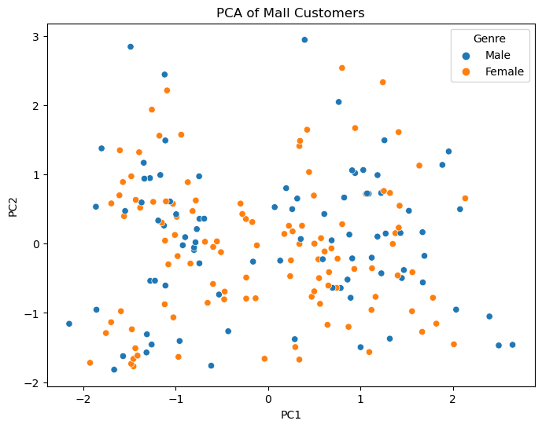

```python
## Data Reduction
# Dimensionality Reduction using PCA

from sklearn.decomposition import PCA
from sklearn.preprocessing import StandardScaler

# Load the dataset
url = 'http://bit.ly/MallCustomersDataset'
Mall_customers = pd.read_csv(url)

# Selecting numerical features for PCA
features = ['Age', 'Annual Income (k$)', 'Spending Score (1-100)']
x = Mall_customers[features]

# Standardize the data
scaler = StandardScaler()
x_scaled = scaler.fit_transform(x)

# Applying PCA
pca = PCA(n_components=2)
principal_components = pca.fit_transform(x_scaled)

# Creating a DataFrame with the principal components
pca_df = pd.DataFrame(data=principal_components, columns=['PC1', 'PC2'])

# Concatenating with the original Genre column
final_df = pd.concat([pca_df, Mall_customers[['Genre']]], axis=1)

print(final_df.head())

# Visualizing the results
plt.figure(figsize=(8, 6))
sns.scatterplot(x='PC1', y='PC2', hue='Genre', data=final_df)
plt.title('PCA of Mall Customers')
plt.show()
```

## 7. Implementing the Solution

```python
## Implementing the Solution
# Feature Selection using Recursive Feature Elimination
from sklearn.feature_selection import RFE
from sklearn.linear_model import LogisticRegression

# Load the dataset
url = 'http://bit.ly/MallCustomersDataset'
Mall_customers = pd.read_csv(url)

# Preparing data for RFE
X = Mall_customers[['Age', 'Annual Income (k$)', 'Spending Score (1-100)']]
y = Mall_customers['Genre'].apply(lambda x: 1 if x == 'Male' else 0)

# Using Logistic Regression as the model
model = LogisticRegression()

# Applying RFE
rfe = RFE(model, n_features_to_select=2)
fit = rfe.fit(X, y)

print("Num Features: %s" % (fit.n_features_))
print("Selected Features: %s" % (fit.support_))
print("Feature Ranking: %s" % (fit.ranking_))

selected_features = X.columns[fit.support_]
print("Selected features: ", selected_features)

## Sampling
# Load the dataset
url = 'http://bit.ly/MallCustomersDataset'
Mall_customers = pd.read_csv(url)

# Sampling 50% of the data
sampled_df = Mall_customers.sample(frac=0.5, random_state=1)

print("Original dataset shape:", Mall_customers.shape)
print("Sampled dataset shape:", sampled_df.shape)

## Aggregation
# Suppose we had a 'Date' column and we want to aggregate the data by month
# Adding a Date column for demonstration
Mall_customers['Date'] = pd.date_range(start='2020-01-01', periods=len(Mall_customers), freq='D')

# Aggregating data by month
Mall_customers['Month'] = Mall_customers['Date'].dt.to_period('M')
monthly_data = Mall_customers.groupby('Month').agg({
    'Age': 'mean',
    'Annual Income (k$)': 'mean',
    'Spending Score (1-100)': 'mean'
}).reset_index()

print(monthly_data.head())

## Discretization
# Discretizing the 'Annual Income (k$)' column into bins
Mall_customers['Income_Bin'] = pd.cut(Mall_customers['Annual Income (k$)'], bins=5, labels=False)

print(Mall_customers[['Annual Income (k$)', 'Income_Bin']].head())
```

```
Num Features: 2
Selected Features: [ True  True False]
Feature Ranking: [1 1 2]
Selected features:  Index(['Age', 'Annual Income (k$)'], dtype='object')
Original dataset shape: (200, 5)
Sampled dataset shape: (100, 5)
     Month        Age  Annual Income (k$)  Spending Score (1-100)
0  2020-01  35.354839           21.741935               48.903226
1  2020-02  39.206897           39.034483               50.448276
2  2020-03  46.387097           51.903226               51.677419
3  2020-04  40.366667           62.666667               48.333333
4  2020-05  35.612903           73.451613               52.129032
   Annual Income (k$)  Income_Bin
0                  15           0
1                  15           0
2                  16           0
3                  16           0
4                  17           0
```

## 8. Challenging the solution

> The easy solution is nice because it is, well, easy, but you should never allow those results to hold the day. You should always be thinking of ways to challenge the results, especially if those results comport with your prior expectation.

```
Dataset loaded successfully:
   CustomerID   Genre  Age  Annual Income (k$)  Spending Score (1-100)
0           1    Male   19                  15                      39
1           2    Male   21                  15                      81
2           3  Female   20                  16                       6
3           4  Female   23                  16                      77
4           5  Female   31                  17                      40

Dataset information:
<class 'pandas.core.frame.DataFrame'>
RangeIndex: 200 entries, 0 to 199
Data columns (total 5 columns):
 #   Column                  Non-Null Count  Dtype
---  ------                  --------------  -----
 0   CustomerID              200 non-null    int64
 1   Genre                   200 non-null    object
 2   Age                     200 non-null    int64
 3   Annual Income (k$)      200 non-null    int64
 4   Spending Score (1-100)  200 non-null    int64
dtypes: int64(4), object(1)
memory usage: 7.9+ KB
None

Checking for missing data in each column:
CustomerID                0
Genre                     0
Age                       0
Annual Income (k$)        0
Spending Score (1-100)    0
dtype: int64
```

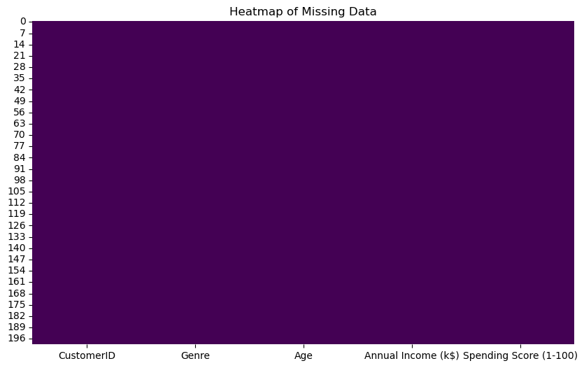

```
Checking for missing data after handling:
CustomerID                0
Genre                     0
Age                       0
Annual Income (k$)        0
Spending Score (1-100)    0
dtype: int64

Summary statistics for numerical columns:
       CustomerID         Age  Annual Income (k$)  Spending Score (1-100)
count  200.000000  200.000000          200.000000              200.000000
mean   100.500000   38.850000           60.560000               50.200000
std     57.879185   13.969007           26.264721               25.823522
min      1.000000   18.000000           15.000000                1.000000
25%     50.750000   28.750000           41.500000               34.750000
50%    100.500000   36.000000           61.500000               50.000000
75%    150.250000   49.000000           78.000000               73.000000
max    200.000000   70.000000          137.000000               99.000000
```

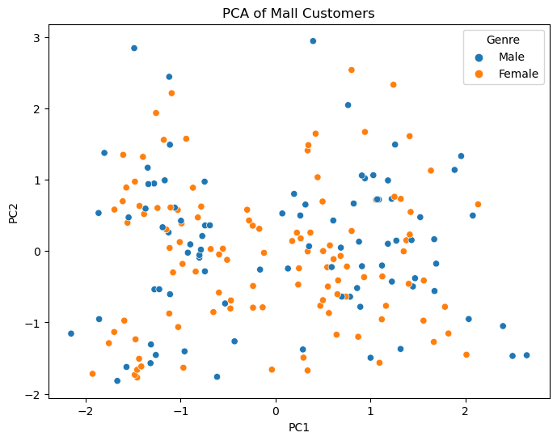

```
Selected features using RFE:  Index(['Age', 'Annual Income (k$)'], dtype='object')

Original dataset shape: (200, 5)
Sampled dataset shape: (100, 5)

Discretization of 'Annual Income (k$)':
   Annual Income (k$)  Income_Bin
0                  15           0
1                  15           0
2                  16           0
3                  16           0
4                  17           0
```

```python
## Reviewing the Solution
import pandas as pd
import seaborn as sns
import matplotlib.pyplot as plt
from sklearn.decomposition import PCA
from sklearn.preprocessing import StandardScaler
from sklearn.feature_selection import RFE
from sklearn.linear_model import LogisticRegression

# Load the dataset
url = 'http://bit.ly/MallCustomersDataset'
Mall_customers = pd.read_csv(url)

# Verify the dataset is loaded correctly
print("\nDataset loaded successfully:")
print(Mall_customers.head())

print("\nDataset information:")
print(Mall_customers.info())

# Check for missing data if any
print("\nChecking for missing data in each column:")
missing_data = Mall_customers.isnull().sum()
print(missing_data)

# Visualize missing data
plt.figure(figsize=(10, 6))
sns.heatmap(Mall_customers.isnull(), cbar=False, cmap='viridis')
plt.title('Heatmap of Missing Data')
plt.show()

# Handling missing data if any
Mall_customers['Age'].fillna(Mall_customers['Age'].mean(), inplace=True)
Mall_customers['Annual Income (k$)'].fillna(Mall_customers['Annual Income (k$)'].mean(), inplace=True)
Mall_customers['Spending Score (1-100)'].fillna(Mall_customers['Spending Score (1-100)'].mean(), inplace=True)
Mall_customers['Genre'].fillna(Mall_customers['Genre'].mode()[0], inplace=True)

# Verify that missing data is handled
print("\nChecking for missing data after handling:")
missing_data_after = Mall_customers.isnull().sum()
print(missing_data_after)

# Summary statistics
print("\nSummary statistics for numerical columns:")
print(Mall_customers.describe())

# Dimensionality Reduction using PCA
features = ['Age', 'Annual Income (k$)', 'Spending Score (1-100)']
x = Mall_customers[features]

# Standardize the data
scaler = StandardScaler()
x_scaled = scaler.fit_transform(x)

# Applying PCA
pca = PCA(n_components=2)
principal_components = pca.fit_transform(x_scaled)

# Creating a DataFrame with the principal components
pca_df = pd.DataFrame(data=principal_components, columns=['PC1', 'PC2'])

# Concatenating with the original Genre column
final_df = pd.concat([pca_df, Mall_customers[['Genre']]], axis=1)

# Visualizing the results
plt.figure(figsize=(8, 6))
sns.scatterplot(x='PC1', y='PC2', hue='Genre', data=final_df)
plt.title('PCA of Mall Customers')
plt.show()

# Feature Selection using Recursive Feature Elimination (RFE)
X = Mall_customers[['Age', 'Annual Income (k$)', 'Spending Score (1-100)']]
y = Mall_customers['Genre'].apply(lambda x: 1 if x == 'Male' else 0)

# Using Logistic Regression as the model
model = LogisticRegression()

# Applying RFE
rfe = RFE(model, n_features_to_select=2)
fit = rfe.fit(X, y)

selected_features = X.columns[fit.support_]
print("\nSelected features using RFE: ", selected_features)

# Sampling
sampled_df = Mall_customers.sample(frac=0.5, random_state=1)

print("\nOriginal dataset shape:", Mall_customers.shape)
print("Sampled dataset shape:", sampled_df.shape)

# Discretization
Mall_customers['Income_Bin'] = pd.cut(Mall_customers['Annual Income (k$)'], bins=5, labels=False)

print("\nDiscretization of 'Annual Income (k$)':")
print(Mall_customers[['Annual Income (k$)', 'Income_Bin']].head())
```

## 9. Follow up questions

> At this point, we can refine our question or collect new data, all in an iterative process to get at the truth.

### a). Did we have the right data?

### b). Do we need other data to answer our question?

### c). Did we have the right question?